# QTM 151 - Quiz 1

### Submit as an HTML or PDF file

### Print your name below

```python
# Write your answer here
print("Allen")
```

```
Allen
```

### Instructions

This quiz is open book.

- You can use the lecture notes and the internet
- You will get partial credit for attempting the questions
- To get full credit, the code should your as intended
- You should NOT communicate with other students

Print the following message:

"I will abide by Emory's code of conduct"

```python
# Write your answer here:
print("I will abide by Emory's code of conduct")
```

```
I will abide by Emory's code of conduct
```

### Import the libraries "numpy", "matplotlib.pytplot", and "pandas"

```python
# Write your answer here
import numpy as np
import matplotlib.pyplot as plt
import pandas as pd
```

### (a) Transform a list of values and plot it

- Create an array with the following values
- `vec_x = [-5,-3, 0, 10, 20, 40]`
- Create a new vector `vec_y` with the following formula
- $\qquad y = [cos(x)]^2$
- Produce a scatter plot of `vec_y` against `vec_x`
- Label the axes and the title
- Change the color to `red`, `green`, or `purple` (you choose)
- **Hint**: You can use the `numpy` functions

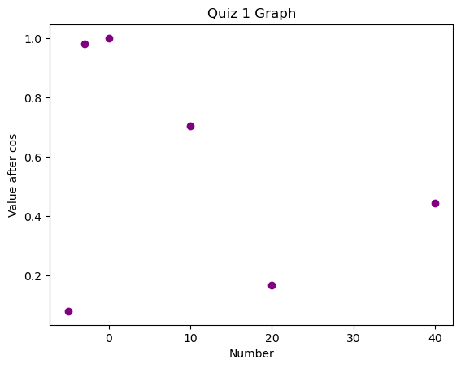

```python
# Write your answer here:
import numpy as np
import matplotlib.pyplot as plt
import pandas as pd

vec_x = [-5,-3,0,10,20,40]
vec_y = [np.cos(vec_x)**2]

plt.scatter(vec_x, vec_y, c="purple")
plt.xlabel("Number")
plt.ylabel("Value after cos")
plt.title("Quiz 1 Graph")
plt.show()
```

### (b) IF/ELSE statements

- Create two lists:
- `list_fruits = ["apple","orange","pear","banana"]`
- `list_colors = ["blue","red","green","orange"]`
- Create a new variable `message = "orange"`
- Create an if/else that tests whether `message` is a fruit and a color. Print a message if the test is true.
- **Hint**: Use the `in` command to test whether an element is part of a list (see Lecture 4)

```python
# Write your answer here:
list_fruits = ["apple","orange","pear","banana"]
list_colors = ["blue","red","green","orange"]

message = "orange"

if message in list_fruits and message in list_colors:
    print("The test is true")
```

```
The test is true
```

### (c) Plot random variables

- Let $n = 1000$
- Generate `vec_x` from a Normal with (loc = 2, scale = 1, size = n)
- Generate `vec_z` from a chi square with (df = 2, size = n)
- Generate `vex_y` from a uniform with (low = 5,high = 10, size = n)
- Plot two scatter plots: (`vec_y` vs `vec_x`) and (`vec_z` vs `vec_x`)
  - Label the axes and title
  - Each graph should have a different title
- To get full points, plot the scatter plots on a single row using the `subplots` syntax (see Lecture 6)

[figure not shown]

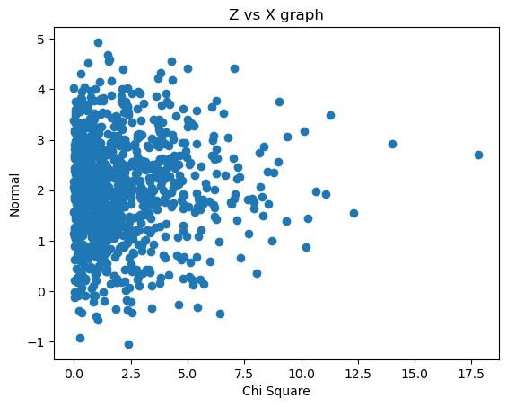

```python
# Write your answer here:
n = 1000
vec_x = np.random.normal(loc=2, scale=1, size=n)
vec_z = np.random.chisquare(df=2, size=n)
vec_y = np.random.uniform(low=5, high=10, size=n)
plt.scatter(vec_y, vec_x)
plt.xlabel("Uniform")
plt.ylabel("Chi square")
plt.title("X vs Y graph")
plt.show()

plt.scatter(vec_z, vec_x)
plt.xlabel("Chi Square")
plt.ylabel("Normal")
plt.title("Z vs X graph")
plt.show()
```

### (d) Create the following list of months:

`list_months = ["August","February"]`

`list_spring_semester = ["January", "February", "March", "April", "May"]`

Create a for-loop that checks whether each element of `list_months` belongs to the spring semester. Create a message with this result.

The output generated by your loop should look like this:

`"August is NOT part of the Spring semester"`

`"February is part of the Spring semester"`

- **Hint**: Use if/else statements inside the loop. You can use the command "in" (see Lecture 4) to test whether an element belongs to a list

```python
# Write your answer here:
list_months = ["August","February"]
list_spring_semester = ["January", "February", "March", "April", "May"]
index = 0
for index in list_months:
    if index in list_spring_semester:
        print(index + " is part of the Spring semester")
    else:
        print(index + " is not part of the Spring semester")
```

```
August is not part of the Spring semester
February is part of the Spring semester
```

### (e) Loop through dfferent variables and plot

- Read the dataset `data_quiz/wdi_ageprop_2020.csv`
- Create a list of variable names with the following elements:

`list_varnames = ["percent_ages0to14","percent_ages15to64"]`

- Run a for loop that creates a histogram plot for each of the variables on the list
- Label the axes (the y-axis can be called "Frequency")
- The loop should automatically create titles that look like this:
  - "Distribution for percent_ages0to14"
  - "Distribution for percent_ages15to64"

Note: This exercise tells you how much the proportion of the populaton in different ages varies across countries in 2020.

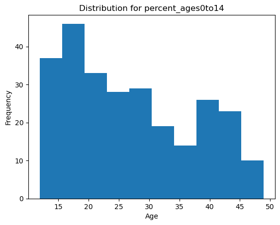

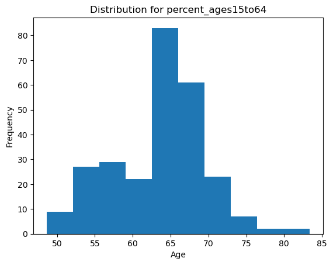

```python
# Write your answer here:
file_path = '/Users/allenhung/Documents/GitHub/qtm151/quizzes/data_quiz/wdi_ageprop_2020.csv'
wdi = pd.read_csv(file_path)

list_varnames = ["percent_ages0to14","percent_ages15to64"]

for index in list_varnames:
    plt.hist(wdi[index])
    plt.title("Distribution for " + index)
    plt.xlabel("Age")
    plt.ylabel("Frequency")
    plt.show()
```

### (f) Run loop through different datasets and compute statistics

- Create a list with the `.csv` dataset names (including their relative subfolder `data_quiz/`)
- Run a for-loop over the list of dataset names. Inside the loop:
  - Read the corresponding `.csv` dataset.
  - Print the mean of the variable `percent_ages0to14` in each dataset

Note: This exercise tells you how much the proportion of the population that is between 0 and 14 has varied from year to year using real data from the World Development Index.

```python
# Write your answer here:

file_path = '/Users/allenhung/Documents/GitHub/qtm151/quizzes/data_quiz/wdi_ageprop_2020.csv'
file_path1 = '/Users/allenhung/Documents/GitHub/qtm151/quizzes/data_quiz/wdi_ageprop_2000.csv'
file_path2 = '/Users/allenhung/Documents/GitHub/qtm151/quizzes/data_quiz/wdi_ageprop_1980.csv'

wdi = pd.read_csv(file_path)
list = [file_path, file_path1, file_path2]

for index in list:
    wdi = pd.read_csv(index)
    print(np.mean(wdi["percent_ages0to14"]))
```

```
26.90657125728302
32.17265501184906
36.82095078354717
```